# Analyse factorielle discriminante

Paul Cascarino et Mathis Quinio-Cosquer

Décembre 2023

# Projet 2 :

## 1. Introduction

### Les objectifs du projet

Le but de ce projet est de réduire la dimensionnalité des données de tweet afin de visualiser le regroupement de sentiments.

## 2. Chargement et exploration des données

### Préparation et imports

Dans un premier temps, nous effaçons la mémoire :

```r
rm(list=ls())
```

Et faisons les chargements des packages nécessaires :

```r
library(dplyr)
```

```r
library(ggplot2)
library(stringr)

# Permet la tokenization : https://smltar.com/tokenization#types-of-tokens
library(tokenizers)
# Permet l'utilisation de liste pour le stop-words : https://smltar.com/stopwords#premadestopwords
library(stopwords)
# Permet la stemmatization : https://smltar.com/stemming#how-to-stem-text-in-r
library(SnowballC)

library(tm)
library(text2vec)
library(slam)

# Installer et charger le package 'MASS' pour l'Analyse Discriminante Linéaire (LDA)
# install.packages("MASS")
library(MASS)
```

### Chargement des données

Les données sont récupérés sur le site kaggle à l’adresse : https://www.kaggle.com/datasets/jp797498e/twitter-entity-sentiment-analysis Nous pouvons ainsi récupérer le csv récupéré avec :

```r
df_train <- read.csv('data/twitter_training.csv', header=FALSE)
df_test <- read.csv('data/twitter_validation.csv', header=FALSE)

head(df_train)
```

```
##     V1          V2       V3
## 1 2401 Borderlands Positive
## 2 2401 Borderlands Positive
## 3 2401 Borderlands Positive
## 4 2401 Borderlands Positive
## 5 2401 Borderlands Positive
## 6 2401 Borderlands Positive
##                                                          V4
## 1     im getting on borderlands and i will murder you all ,
## 2       I am coming to the borders and I will kill you all,
## 3        im getting on borderlands and i will kill you all,
## 4       im coming on borderlands and i will murder you all,
## 5 im getting on borderlands 2 and i will murder you me all,
## 6     im getting into borderlands and i can murder you all,
```

**Explication :** Les premières lignes sont des données et non le nom des colonnes D’où le **header=FALSE**

Réduisons nos df :

```r
set.seed(13)

df_train <- df_train[sample(nrow(df_train), 10000),]
```

### Analyse exploratoire des données

```r
dim(df_train)
```

```
## [1] 10000     4
```

```r
dim(df_test)
```

```
## [1] 1000    4
```

Ajoutons des noms aux colonnes dans nos df pour plus de simplicité:

```r
names <- c('tweet_id', 'entity', 'sentiment', 'content')
colnames(df_train) <- names
colnames(df_test) <- names

colnames(df_train)
```

```
## [1] "tweet_id"  "entity"    "sentiment" "content"
```

Convertissons les variables catégorielles en facteurs

```r
df_train$sentiment <- as.factor(df_train$sentiment)
df_train$entity <- as.factor(df_train$entity)
df_test$sentiment <- as.factor(df_test$sentiment)
df_test$entity <- as.factor(df_test$entity)
```

```r
sum(duplicated(df_train))
```

```
## [1] 60
```

```r
sum(duplicated(df_test))
```

```
## [1] 0
```

Supprimons les avec :

```r
df_train <- unique(df_train)
df_test <- unique(df_test)
```

Nous requons aussi qu’il n’y a pas d’éléments nuls

```r
sum(is.na(df_train))
```

```
## [1] 0
```

```r
sum(is.na(df_test))
```

```
## [1] 0
```

#### La colonne ‘entity’

```r
df_train$entity[23332:23334]
```

```
## [1] <NA> <NA> <NA>
## 32 Levels: Amazon ApexLegends AssassinsCreed Battlefield ... Xbox(Xseries)
```

```r
entity_dist <- factor(df_train$entity)
levels(entity_dist)
```

```
##  [1] "Amazon"                            "ApexLegends"
##  [3] "AssassinsCreed"                    "Battlefield"
##  [5] "Borderlands"                       "CallOfDuty"
##  [7] "CallOfDutyBlackopsColdWar"         "CS-GO"
##  [9] "Cyberpunk2077"                     "Dota2"
## [11] "Facebook"                          "FIFA"
## [13] "Fortnite"                          "Google"
## [15] "GrandTheftAuto(GTA)"               "Hearthstone"
## [17] "HomeDepot"                         "johnson&johnson"
## [19] "LeagueOfLegends"                   "MaddenNFL"
## [21] "Microsoft"                         "NBA2K"
## [23] "Nvidia"                            "Overwatch"
## [25] "PlayerUnknownsBattlegrounds(PUBG)" "PlayStation5(PS5)"
## [27] "RedDeadRedemption(RDR)"            "TomClancysGhostRecon"
## [29] "TomClancysRainbowSix"              "Verizon"
## [31] "WorldOfCraft"                      "Xbox(Xseries)"
```

```r
length((levels(entity_dist)))
```

```
## [1] 32
```

Nous avons donc une liste de 32 entités, regardons la répartition dans le dataframe d’entrainement.

```r
min(table(df_train$entity))
```

```
## [1] 292
```

```r
max(table(df_train$entity))
```

```
## [1] 352
```

[output not shown]

```
## [1] "Irrelevant" "Negative"   "Neutral"    "Positive"
```

```r
length((levels(sentiment_dist)))
```

```
## [1] 4
```

Nous avons donc une liste de 4 sentiments : “Irrelevant” “Negative” “Neutral” “Positive”

Regardons la répartition des sentiments à l’aide d’un pie chart créé lors du mini projet 1 :

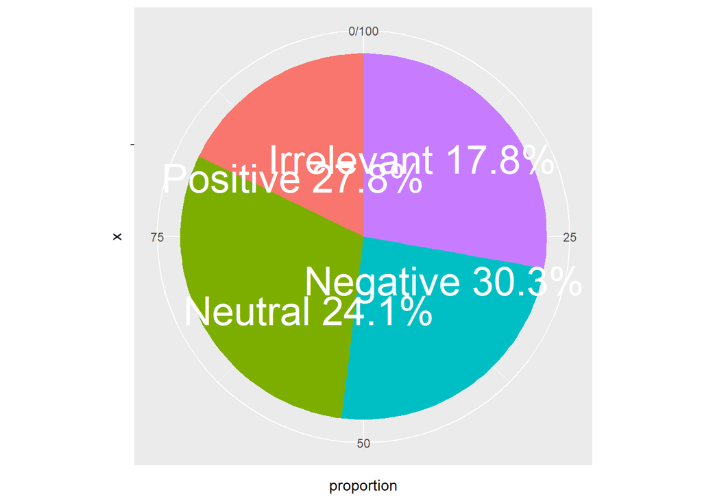

```r
pie_chart <- function(sentiment) {
  train_df <- data.frame(
    Count = table(sentiment)
  )
  colnames(train_df) <- c('sentiment', 'Count')

  train_df <- train_df %>%
                  mutate(proportion = Count / sum(train_df$Count) * 100) %>%
                  mutate(ypos = cumsum(proportion)- 0.5*proportion)

  pie_chart <- ggplot(train_df, aes(x='', y=proportion, fill=sentiment)) +
                geom_bar(stat='identity', width=1) +
                coord_polar('y', start=0) +
                theme(legend.position='none') +
                geom_text(aes(x ='', y=ypos, label=paste(sentiment, sprintf("%.1f%%", proportion))), color='white', size = 10)

  pie_chart
}

pie_chart(sentiment_dist)
```

Nous remarquons que nous avons une répartition inégale de tweet en fonction des sentiments. Cela sera peut être à prendre en compte pour améliorer notre modèle en fonction des poids de chacuns.

#### La colonne content :

Regardons la répartition des longueurs des chaines de caractères en fonction des sentiments : (Graph crée avec le mini-projet 1)

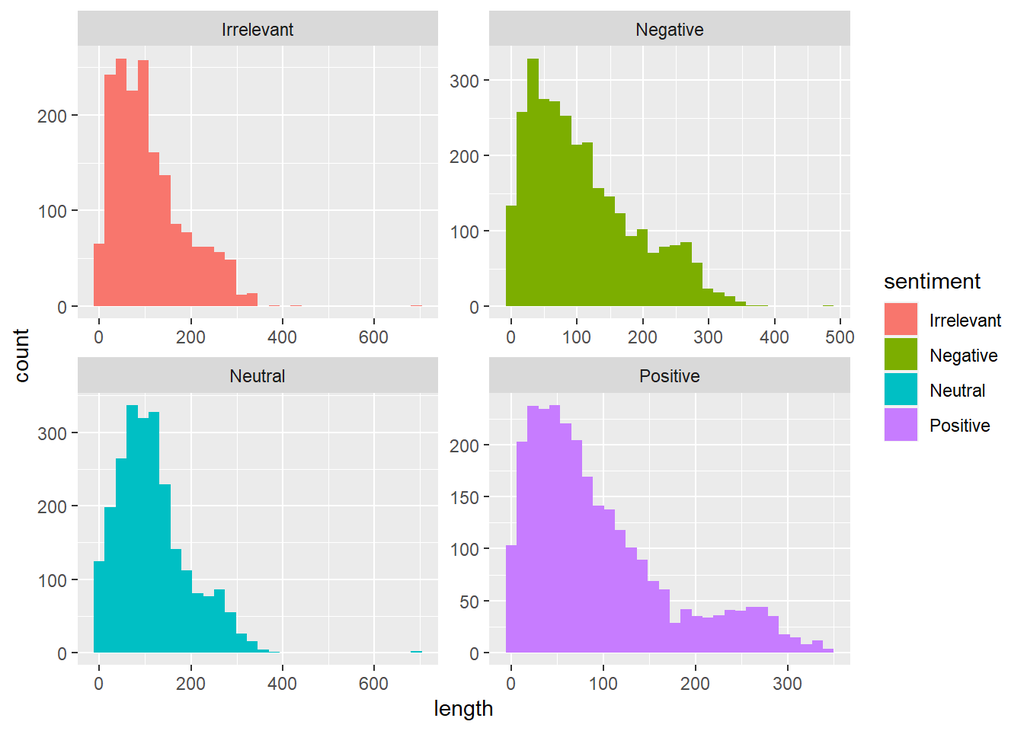

```r
nchar_df <- data.frame(length = nchar(df_train$content), sentiment = df_train$sentiment)

plot <- ggplot(nchar_df, aes(x=length, fill=sentiment)) +
          geom_histogram(position='identity') +
          facet_wrap(~sentiment, scales='free')

plot
```

Nous remarquons une répartition assez similaire entre les 4 valeurs de sentiments, la longueur des chaînes de caractères ne permettrait donc pas d’avoir des informations utiles facilement.

### 3. Ingénierie des caractéristiques :

#### Traitement de la colonne content

Pour cela nous allons créer une fonction qui vas : - mettre tous les textes en minuscule - supprimer les chiffres - supprimer tous les caractères spéciaux

```r
clean_text <- function(df_col){
  temp_col <- str_to_lower(df_col)
  temp_col <- str_replace_all(temp_col, "[0-9]", "")
  temp_col <- str_replace_all(temp_col, "[^[:alnum:][:space:]]", "")
  return(temp_col)
}

df_train$content <- clean_text(df_train$content)
df_test$content <- clean_text(df_test$content)

head(df_train$content)
```

```
## [1] "here  s s a nice little k on the most popular spot on board the skell port of pvp information map"
## [2] "how yall got glow in the dark spongebob bandaids but not multiple flesh tonesfor  years thats fucked"
## [3] "astonishing"
## [4] " sammobileus i opened  google streetview on my samsung and now my phone screen has stopped working properly"
## [5] "an hour later still on the phone with  "
## [6] "new microsoft documents reveal exciting surface design  forbes iftttcimr"
```

La fonction **clean_text** nous permet de supprimer les caractères non alphanumériques et les chiffres ainsi que de touus mettre en minuscule.

Nous pouvons maintenant apppliquer la Tokenization :

#### Tokenization

https://smltar.com/tokenization

Nous décidons dans un premier temps de faire une tokenization par mots car c est la méthode la plus commune et que cela nous parait logique de travailler dans un premier temps avec les mots.

De plus nous avons vu grâce au mini projet 1 que c’est la plus performante par rapports à la tokenization ppar pluusieurs mots en terme d’accuracy :

```r
df_train$token <- tokenize_words(df_train$content)
df_test$token <- tokenize_words(df_test$content)

head(df_train$token)
```

```
## [[1]]
##  [1] "here"        "s"           "s"           "a"           "nice"
##  [6] "little"      "k"           "on"          "the"         "most"
## [11] "popular"     "spot"        "on"          "board"       "the"
## [16] "skell"       "port"        "of"          "pvp"         "information"
## [21] "map"
##
## [[2]]
##  [1] "how"       "yall"      "got"       "glow"      "in"        "the"
##  [7] "dark"      "spongebob" "bandaids"  "but"       "not"       "multiple"
## [13] "flesh"     "tonesfor"  "years"     "thats"     "fucked"
##
## [[3]]
## [1] "astonishing"
##
## [[4]]
##  [1] "sammobileus" "i"           "opened"      "google"      "streetview"
##  [6] "on"          "my"          "samsung"     "and"         "now"
## [11] "my"          "phone"       "screen"      "has"         "stopped"
## [16] "working"     "properly"
##
## [[5]]
## [1] "an"    "hour"  "later" "still" "on"    "the"   "phone" "with"
##
## [[6]]
## [1] "new"       "microsoft" "documents" "reveal"    "exciting"  "surface"
## [7] "design"    "forbes"    "iftttcimr"
```

Nous pouvons maintenant observer les tokens les plus utilisés :

Utilisons la fonction duu mini-projet 1 :

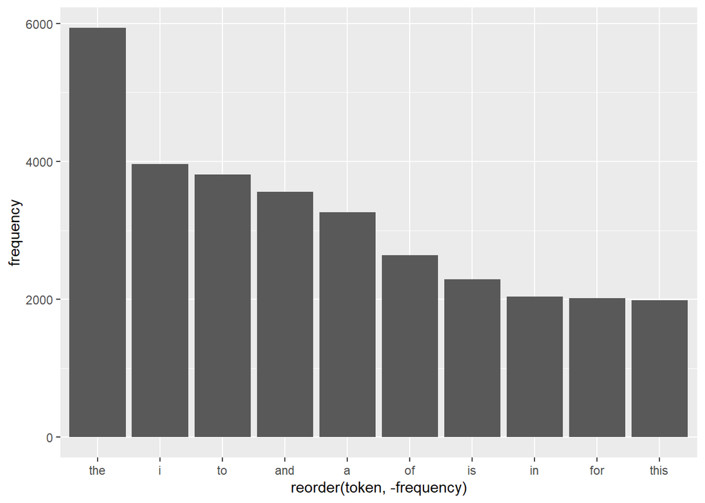

```r
give_most_words <- function(df_tokens, col_names, n){
  token_freq <- table(unlist(df_tokens[[col_names]]))
  token_freq_df <- data.frame(token = names(token_freq), frequency = as.numeric(token_freq))
  token_freq_df <- token_freq_df[order(-token_freq_df$frequency),]
  plot <- ggplot(token_freq_df[0:n,], aes(x=reorder(token, -frequency), y=frequency)) +
            geom_bar(stat = 'identity')
  return(list(plot=plot, df=token_freq_df))
}
result <- give_most_words(df_train[, c('token', 'entity')], 'token', 10)
result$plot
```

**Explication :**

Nous avons définit une fonction qui permet de retourner un graph des n premiers mots et longeurs fréquences d apparition dans notre df.

Nous remarquons que nous avons une liste de mots inutiles. Regardons maintenant les stop words :

##### Stop words

Les **stop words** sont les mots qui n ont pas d intérêts dans le sens de la phrase. Ansi les supprimer réduirait le nombre de feature et donc le nombre de calculs. Nous pouvons aussi penser que réduire les mots inutiles réduirait la performance de notre futur modèle.

Pour cela nous allons utiliser une liste de stop words déjà faite, Nous allons donc utiliser la bibliothèque **smart**

```r
head(stopwords::stopwords(source = "smart"))
```

```
## [1] "a"         "a's"       "able"      "about"     "above"     "according"
```

```r
cat("Nombre de mots avant l'étape des stop words : ",
sum(lengths(df_train$token)))
```

```
## Nombre de mots avant l'étape des stop words :  176808
```

```r
df_train$token <- sapply(df_train$token, function(x) setdiff(x, stopwords::stopwords(source = "smart")))
df_test$token <- sapply(df_test$token, function(x) setdiff(x, stopwords::stopwords(source = "smart")))

result <- give_most_words(df_train[, c('token', 'entity')], 'token', 10)

cat("Nombre de mots après l'étape des stop words : ",
sum(lengths(df_train$token)))
```

```
## Nombre de mots après l'étape des stop words :  82168
```

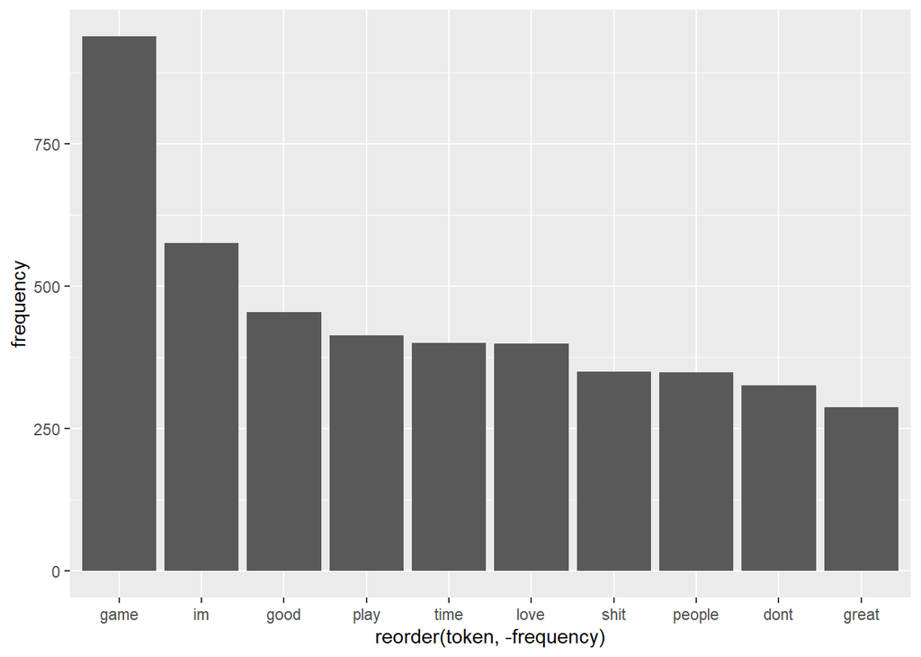

```r
result$plot
```

Nous venons de suupprimer les mots les plus inutiles qui sont dans la bibliothèque **smart**

##### Stemming

Le stemming permet de rapprocher les mots similaires tel que ‘feel’ et ‘feels’ en un stem qui est un mot de base (ex:‘feel’).

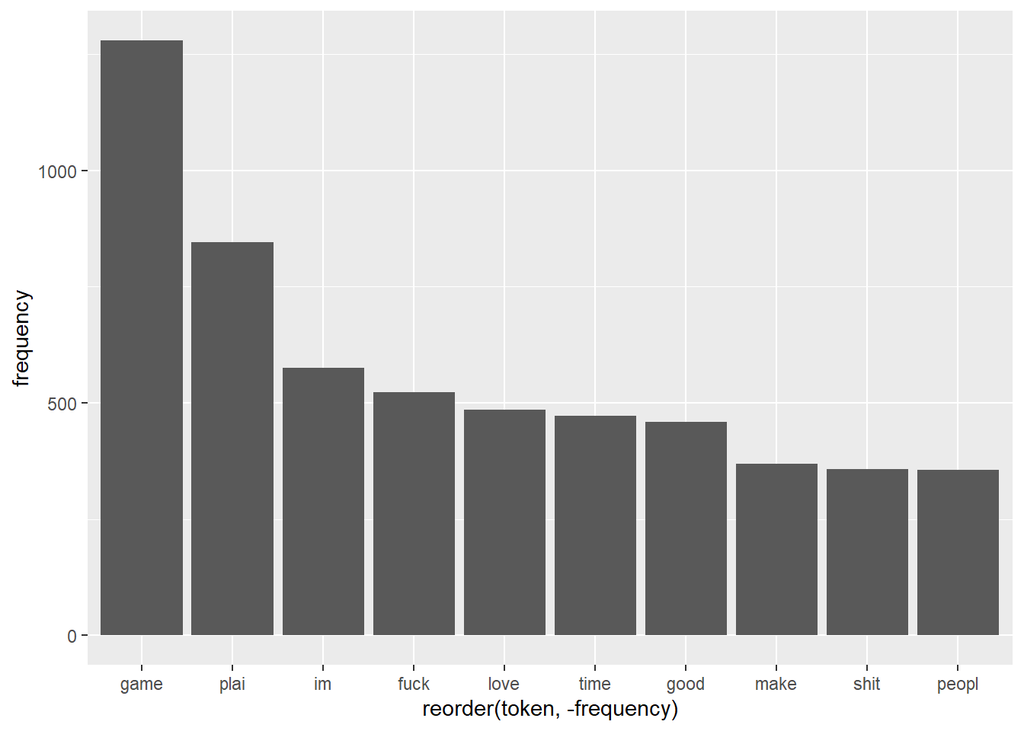

```r
df_train$token <- lapply(df_train$token, function(x) wordStem(x))
df_test$token <- lapply(df_test$token, function(x) wordStem(x))
result <- give_most_words(df_train[, c('token', 'entity')], 'token', 10)

result$plot
```

Nous remarquons que nous avons rassembler des mots similaires entre eux.

##### TF-IDF

On a :
$$\text{IDF}(t, D) = \log\left(\frac{N}{\text{df}(t)}\right)$$
avec

- N : le nombre documents total
- df(t) : le nombre de documents comportant le terme t

```r
give_tfidf <- function(df_train, df_test, term_count_min){

    # Créer un itoken
  itoken_train <- itoken(df_train$token)
  itoken_test <- itoken(df_test$token)

  # Créer le vocabulaire
  vocabulary <- create_vocabulary(itoken_train)
  vocabulary <- prune_vocabulary(vocabulary, term_count_min)

  vectorizer <- vocab_vectorizer(vocabulary)

  dtm_train <- create_dtm(itoken_train, vectorizer)
  dtm_test <- create_dtm(itoken_test, vectorizer)

  train_matrix <- as.matrix(as(dtm_train, "CsparseMatrix"))
  test_matrix <- as.matrix(as(dtm_test, "CsparseMatrix"))

  return(list(train = train_matrix, test = test_matrix))
}
tfidfs <- give_tfidf(df_train, df_test, 5)

df_train$tfidf <- tfidfs$train
df_test$tfidf <- tfidfs$test
```

###4. Entrainement, amélioration, visualisation du modèle et de nos données

L’AFD est utilisé pour réduire la dimensionnalité de nos données. Dans notre exemple nous avons 3 colonne pour utiles ce qui difficilement visualisable.

Ainsi l’AFD peut aider à révéler des tendances et des clusters entre les tweets.

Appliquons maintenant l’AFD avec LDA (Analyse Discriminante Linéaire)

```r
afd_model <- MASS::lda(sentiment ~ tfidf + entity, data = df_train)
selected_columns <- c("tfidf", "entity", "sentiment")
projected_data <- predict(afd_model, newdata = df_test[selected_columns])$x
```

[figure not shown]

```r
# Visualisation des résultats de l'AFD en deux dimensions
plot(projected_data[, 1], projected_data[, 2], col = as.factor(df_test$sentiment),
     pch = 19, main = "Visualisation des résultats de l'AFD", xlab = "LD1", ylab = "LD2")

# Légende
legend("topright", legend = levels(as.factor(df_test$sentiment)), col = 1:3, pch = 19, title = "Sentiment")
```

```r
# Évaluation du modèle (précision dans ce cas)
predicted_labels <- predict(afd_model, newdata = df_test)$class
accuracy <- sum(predicted_labels == df_test$sentiment) / length(df_test$sentiment)

cat("Précision du modèle : ", accuracy)
```

```
## Précision du modèle :  0.642
```

## 5. Conclusion et travaux à venir

### Améliorations possibles

Nous n’avons pas eu le temps de faire la validation croisé de manière convenable ainsi que la présentation des résultats. Nous nous sommes donc concentrés sur le travail en fouille et permettre d’obtenir le meilleur preprocessing car les aspects manquants sont dévelopés dans d’autres matières. (en python).